# Exploratory_data_analysis_R4DS

Noelí D’Alessio

5/4/2020

#Exploratory Data Analysis

```r
library("tidyverse")
library("viridis")
library("nycflights13")
library("ggbeeswarm")
```

```r
library("lvplot")
library("ggstance")
```

### 1. Explore the distribution of each of the x, y, and z variables in diamonds. What do you learn? Think about a diamond and how you might decide which dimension is the length, width, and depth.

x length in mm (0-10.74) y width in mm (0-58.9) z depth in mm (0-31.8)

```r
summary(select(diamonds, x, y, z))
```

```
##        x                y                z
##  Min.   : 0.000   Min.   : 0.000   Min.   : 0.000
##  1st Qu.: 4.710   1st Qu.: 4.720   1st Qu.: 2.910
##  Median : 5.700   Median : 5.710   Median : 3.530
##  Mean   : 5.731   Mean   : 5.735   Mean   : 3.539
##  3rd Qu.: 6.540   3rd Qu.: 6.540   3rd Qu.: 4.040
##  Max.   :10.740   Max.   :58.900   Max.   :31.800
```

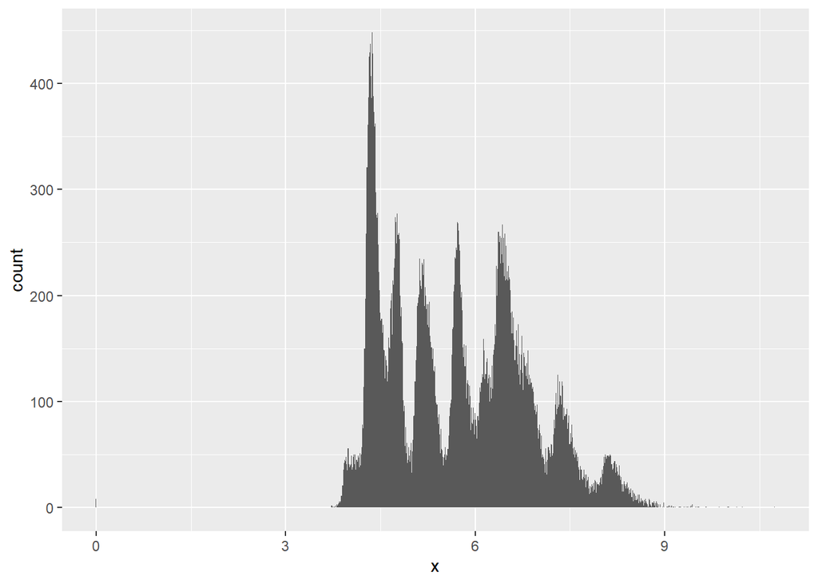

```r
ggplot(data = diamonds) +
    geom_histogram(mapping = aes(x = x), binwidth = 0.01)
```

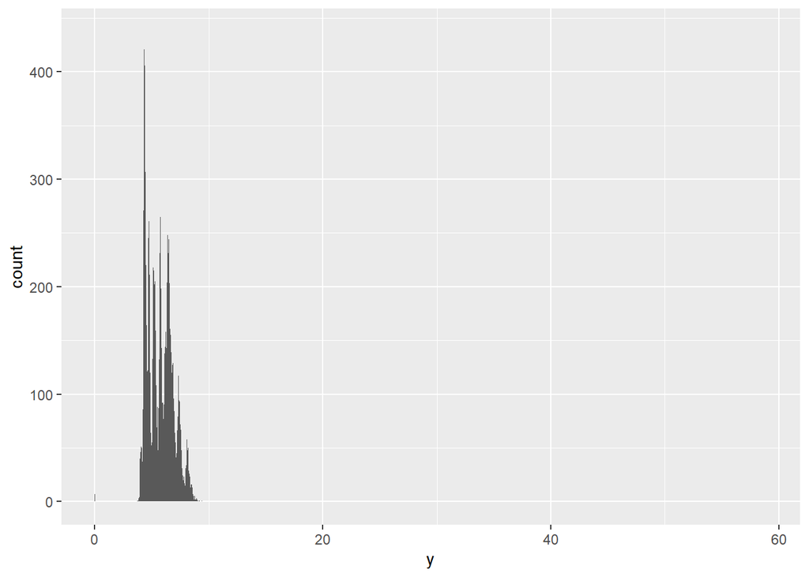

```r
ggplot(data = diamonds) +
    geom_histogram(mapping = aes(x = y), binwidth = 0.01)
```

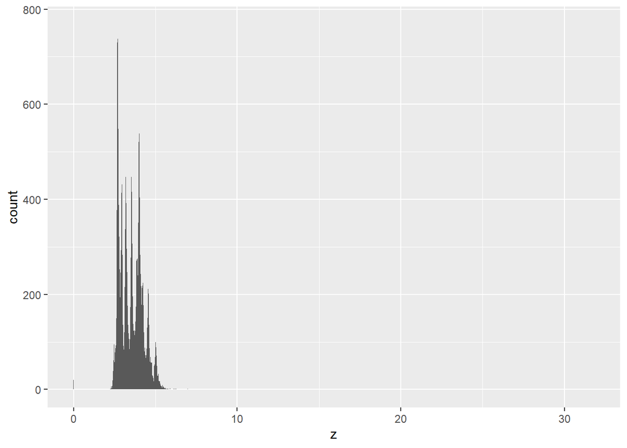

```r
ggplot(data = diamonds) +
    geom_histogram(mapping = aes(x = z), binwidth = 0.01)
```

Typical values of X go from 4.710 to 6.540. Typical values of Y go from de 4.720 to 6.540. Typical values of Z go from 2.910 to 4.040. Es decir, los valores típicos de X e Y are larger than Z’s values.

Otliers values: 0 and some are large values for X, Y, and Z.

```r
filter(diamonds, x == 0 | y == 0 | z == 0)
```

```
## # A tibble: 20 x 10
##    carat cut       color clarity depth table price     x     y     z
##    <dbl> <ord>     <ord> <ord>   <dbl> <dbl> <int> <dbl> <dbl> <dbl>
##  1  1    Premium   G     SI2      59.1    59  3142  6.55  6.48     0
##  2  1.01 Premium   H     I1       58.1    59  3167  6.66  6.6      0
##  3  1.1  Premium   G     SI2      63      59  3696  6.5   6.47     0
##  4  1.01 Premium   F     SI2      59.2    58  3837  6.5   6.47     0
##  5  1.5  Good      G     I1       64      61  4731  7.15  7.04     0
##  6  1.07 Ideal     F     SI2      61.6    56  4954  0     6.62     0
##  7  1    Very Good H     VS2      63.3    53  5139  0     0        0
##  8  1.15 Ideal     G     VS2      59.2    56  5564  6.88  6.83     0
##  9  1.14 Fair      G     VS1      57.5    67  6381  0     0        0
## 10  2.18 Premium   H     SI2      59.4    61 12631  8.49  8.45     0
## 11  1.56 Ideal     G     VS2      62.2    54 12800  0     0        0
## 12  2.25 Premium   I     SI1      61.3    58 15397  8.52  8.42     0
## 13  1.2  Premium   D     VVS1     62.1    59 15686  0     0        0
## 14  2.2  Premium   H     SI1      61.2    59 17265  8.42  8.37     0
## 15  2.25 Premium   H     SI2      62.8    59 18034  0     0        0
## 16  2.02 Premium   H     VS2      62.7    53 18207  8.02  7.95     0
## 17  2.8  Good      G     SI2      63.8    58 18788  8.9   8.85     0
## 18  0.71 Good      F     SI2      64.1    60  2130  0     0        0
## 19  0.71 Good      F     SI2      64.1    60  2130  0     0        0
## 20  1.12 Premium   G     I1       60.4    59  2383  6.71  6.67     0
```

0 values, missing values?

```r
diamonds %>%
    arrange(desc(y)) %>%
    head(20)
```

```
## # A tibble: 20 x 10
##    carat cut       color clarity depth table price     x     y     z
##    <dbl> <ord>     <ord> <ord>   <dbl> <dbl> <int> <dbl> <dbl> <dbl>
##  1  2    Premium   H     SI2      58.9    57 12210  8.09 58.9   8.06
##  2  0.51 Ideal     E     VS1      61.8    55  2075  5.15 31.8   5.12
##  3  5.01 Fair      J     I1       65.5    59 18018 10.7  10.5   6.98
##  4  4.5  Fair      J     I1       65.8    58 18531 10.2  10.2   6.72
##  5  4.01 Premium   I     I1       61      61 15223 10.1  10.1   6.17
##  6  4.01 Premium   J     I1       62.5    62 15223 10.0   9.94  6.24
##  7  4    Very Good I     I1       63.3    58 15984 10.0   9.94  6.31
##  8  4.13 Fair      H     I1       64.8    61 17329 10     9.85  6.43
##  9  3.67 Premium   I     I1       62.4    56 16193  9.86  9.81  6.13
## 10  3.51 Premium   J     VS2      62.5    59 18701  9.66  9.63  6.03
## 11  3.5  Ideal     H     I1       62.8    57 12587  9.65  9.59  6.03
## 12  3.65 Fair      H     I1       67.1    53 11668  9.53  9.48  6.38
## 13  3.04 Premium   I     SI2      59.3    60 18559  9.51  9.46  5.62
## 14  3.22 Ideal     I     I1       62.6    55 12545  9.49  9.42  5.92
## 15  3.24 Premium   H     I1       62.1    58 12300  9.44  9.4   5.85
## 16  3.01 Fair      H     I1       56.1    62 10761  9.54  9.38  5.31
## 17  3.01 Good      H     SI2      57.6    64 18593  9.44  9.38  5.42
## 18  3.01 Premium   G     SI2      59.8    58 14220  9.44  9.37  5.62
## 19  3.4  Fair      D     I1       66.8    52 15964  9.42  9.34  6.27
## 20  3.01 Premium   J     SI2      59.7    58 18710  9.41  9.32  5.59
```

```r
diamonds %>%
    arrange(desc(z)) %>%
    head(20)
```

```
## # A tibble: 20 x 10
##    carat cut       color clarity depth table price     x     y     z
##    <dbl> <ord>     <ord> <ord>   <dbl> <dbl> <int> <dbl> <dbl> <dbl>
##  1  0.51 Very Good E     VS1      61.8  54.7  1970  5.12  5.15 31.8
##  2  2    Premium   H     SI2      58.9  57   12210  8.09 58.9   8.06
##  3  5.01 Fair      J     I1       65.5  59   18018 10.7  10.5   6.98
##  4  4.5  Fair      J     I1       65.8  58   18531 10.2  10.2   6.72
##  5  4.13 Fair      H     I1       64.8  61   17329 10     9.85  6.43
##  6  3.65 Fair      H     I1       67.1  53   11668  9.53  9.48  6.38
##  7  4    Very Good I     I1       63.3  58   15984 10.0   9.94  6.31
##  8  3.4  Fair      D     I1       66.8  52   15964  9.42  9.34  6.27
##  9  4.01 Premium   J     I1       62.5  62   15223 10.0   9.94  6.24
## 10  4.01 Premium   I     I1       61    61   15223 10.1  10.1   6.17
## 11  2.01 Fair      G     SI2      65.6  56   15562  7.89  7.84  6.16
## 12  3.67 Premium   I     I1       62.4  56   16193  9.86  9.81  6.13
## 13  3.5  Ideal     H     I1       62.8  57   12587  9.65  9.59  6.03
## 14  3.51 Premium   J     VS2      62.5  59   18701  9.66  9.63  6.03
## 15  3.11 Fair      J     I1       65.9  57    9823  9.15  9.02  5.98
## 16  3    Fair      H     I1       67.1  57    8044  8.93  8.84  5.97
## 17  3.22 Ideal     I     I1       62.6  55   12545  9.49  9.42  5.92
## 18  3.02 Fair      I     I1       65.2  56   10577  9.11  9.02  5.91
## 19  3.01 Fair      I     SI2      65.8  56   18242  8.99  8.94  5.9
## 20  3.01 Fair      I     SI2      65.8  56   18242  8.99  8.94  5.9
```

Also did the procedure, arranging descending order by using the X value but X didn’t have any unusual value.

Others outliers: Y= 58.90?, 31.80? Z= 31.80?

To check the consistency of this values with other variables, we carry a scatter plots of each combination X, Y, Z. This shows outliers more clearly.

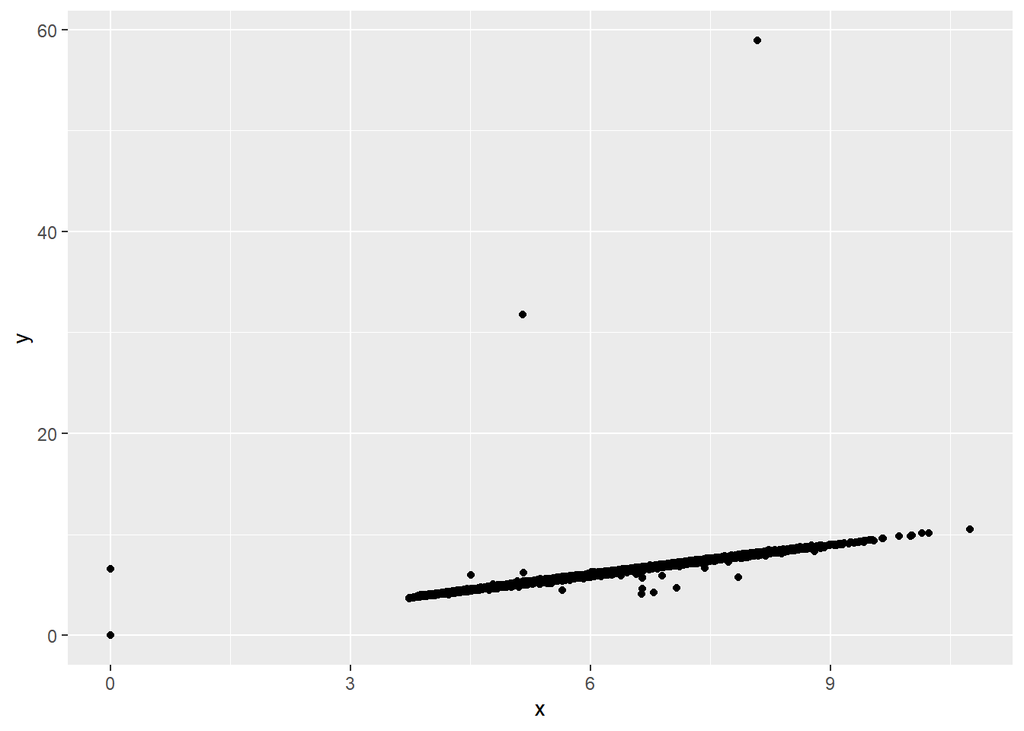

```r
ggplot(diamonds, aes(x = x, y = y)) +
  geom_point()
```

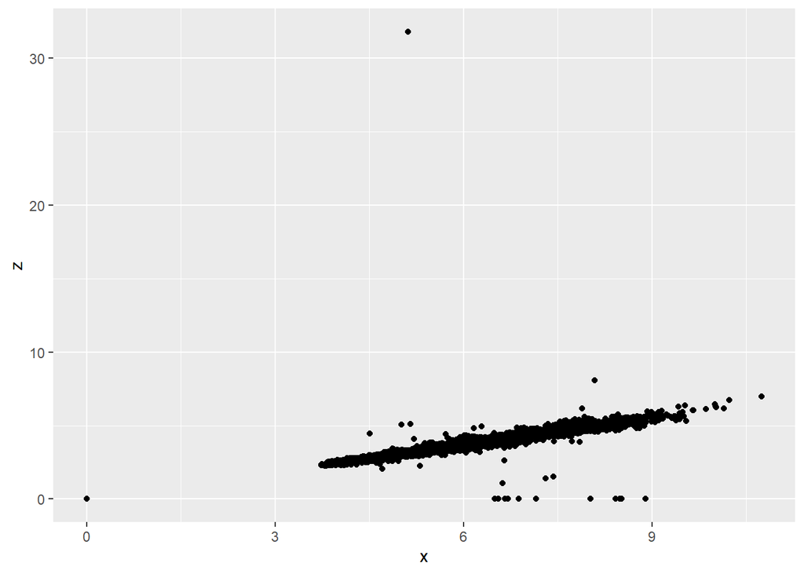

```r
ggplot(diamonds, aes(x = x, y = z)) +
    geom_point()
```

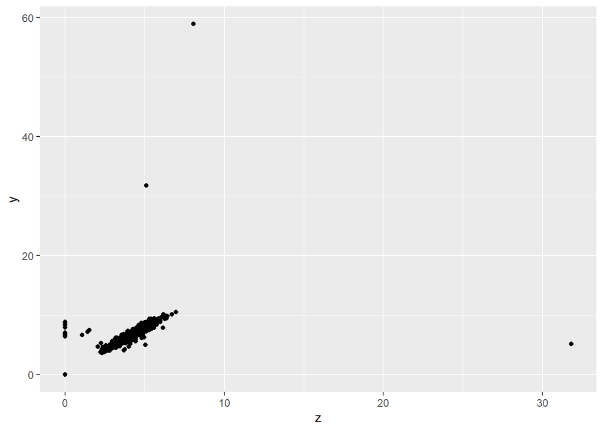

```r
ggplot(diamonds, aes(x = z, y = y))+
  geom_point()
```

To filter the outliers:

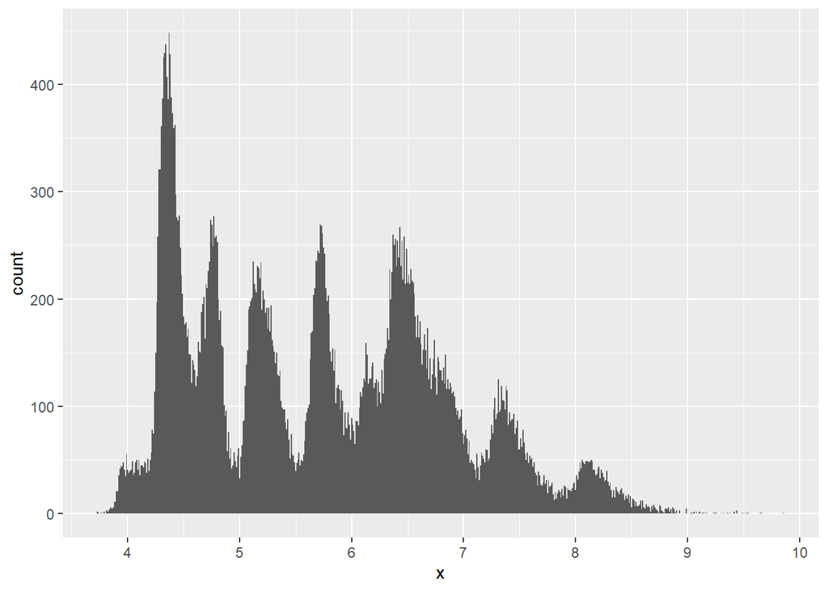

```r
filter(diamonds, x > 0, x < 10) %>%
  ggplot() +
  geom_histogram(mapping = aes(x = x), binwidth = 0.01) +
  scale_x_continuous(breaks = 1:10)
```

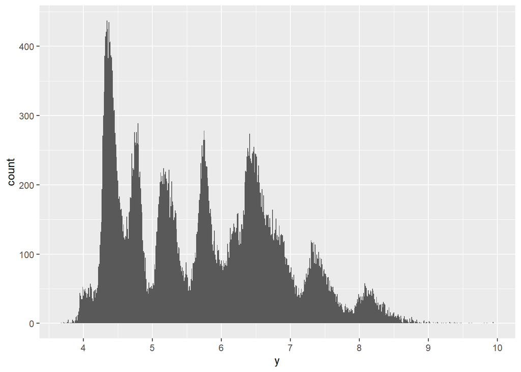

```r
filter(diamonds, y > 0, y < 10) %>%
    ggplot()+
    geom_histogram(mapping = aes(x = y), binwidth = 0.01) +
    scale_x_continuous(breaks = 1:10)
```

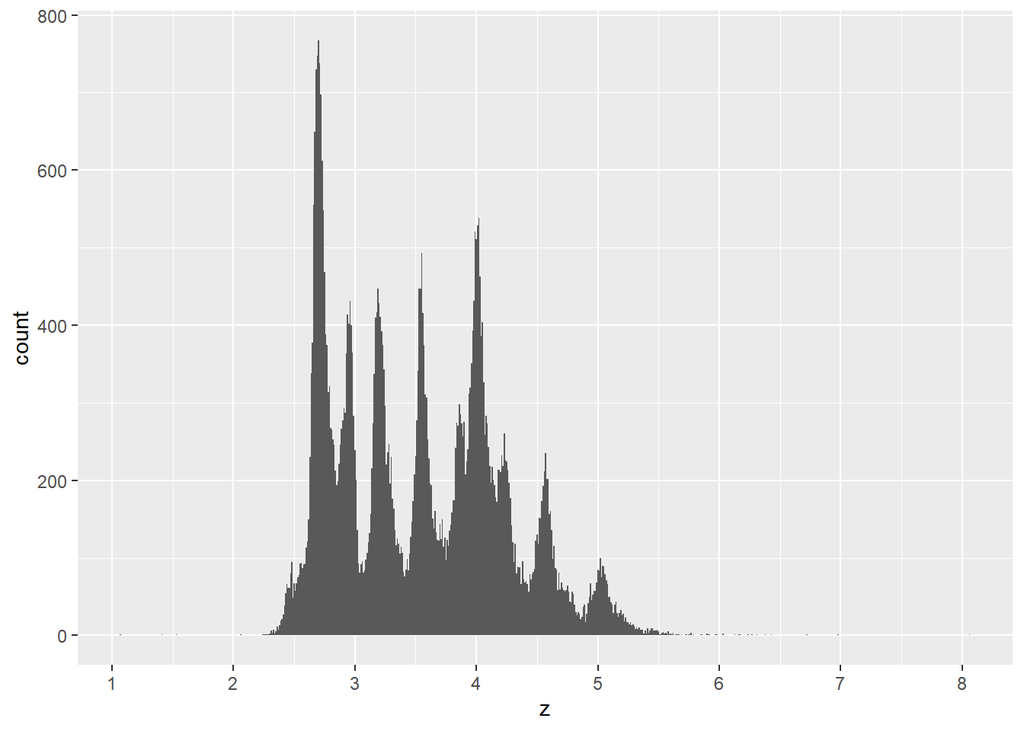

```r
filter(diamonds, z > 0, z < 10) %>%
    ggplot()+
    geom_histogram(mapping = aes(x = z), binwidth = 0.01) +
    scale_x_continuous(breaks = 1:10)
```

### 2. Explore the distribution of price. Do you discover anything unusual or surprising? (Hint: Carefully think about the binwidth and make sure you try a wide range of values.)

```r
summary(select(diamonds, price))
```

```
##      price
##  Min.   :  326
##  1st Qu.:  950
##  Median : 2401
##  Mean   : 3933
##  3rd Qu.: 5324
##  Max.   :18823
```

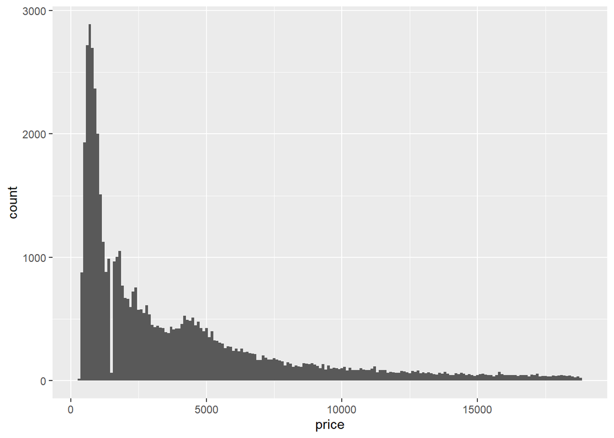

```r
ggplot(data = diamonds) +
    geom_histogram(mapping = aes(x = price), binwidth = 100, center = 0)
```

Not much information in the previous graphic.

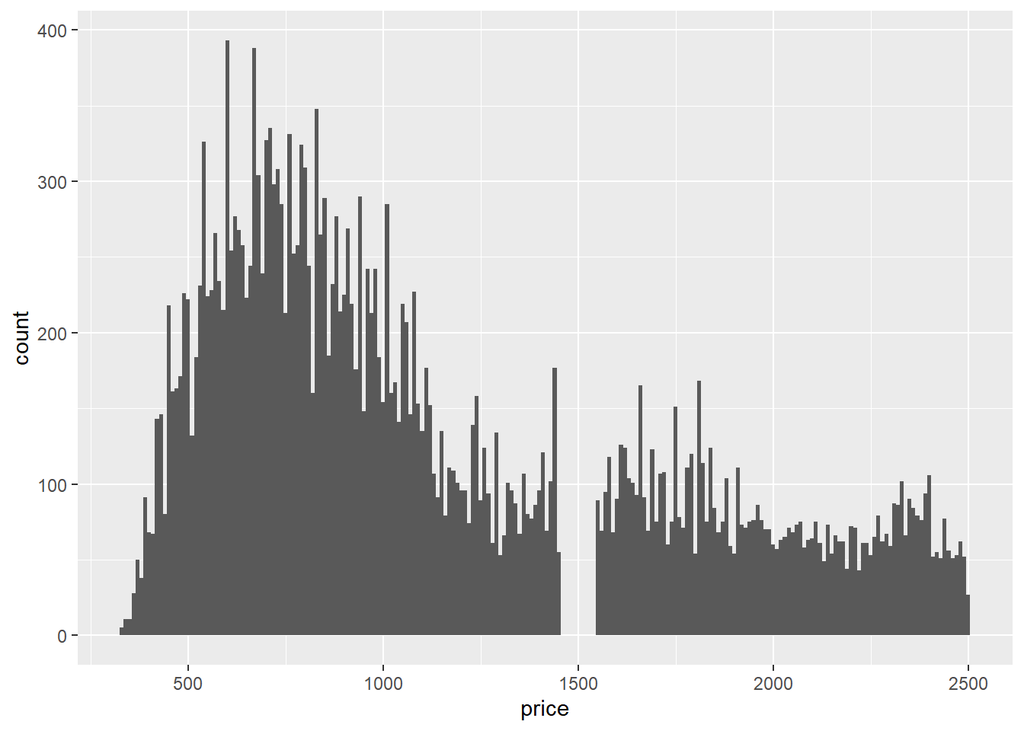

```r
ggplot(filter(diamonds, price < 2500), aes(x = price)) +
    geom_histogram(binwidth = 10, center = 0)
```

-Hay varios picos en la data pero no sé a qué corresponden. -Hay un pico en la distribución en el precio de $750. -No hay diamantes con un precio de $1500 (entre $1450 y $1550).

######Distribución del último dígito

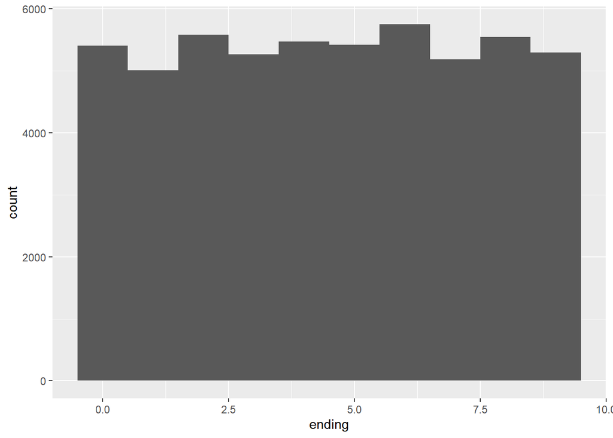

```r
diamonds %>%
    mutate(ending = price %% 10) %>%
    ggplot(aes(x = ending)) +
    geom_histogram(binwidth = 1, center = 0)
```

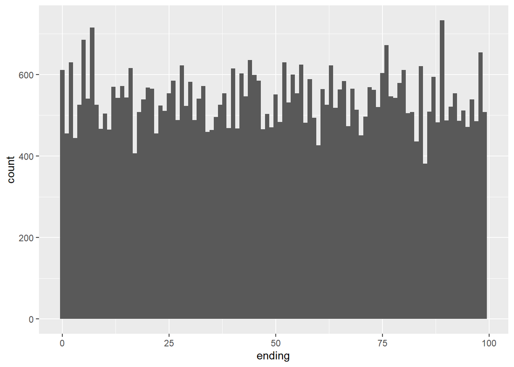

```r
diamonds %>%
    mutate(ending = price %% 100) %>%
    ggplot(aes(x = ending)) +
    geom_histogram(binwidth = 1)
```

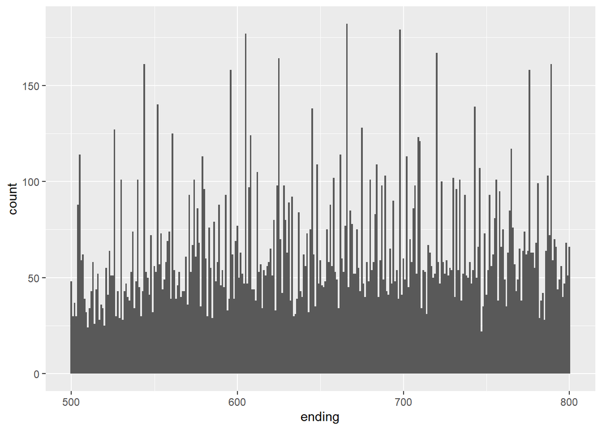

```r
diamonds %>%
    mutate(ending = price %% 1000) %>%
    filter(ending >= 500, ending <= 800) %>%
  ggplot(aes(x = ending)) +
  geom_histogram(binwidth = 1)
```

### How many diamonds are 0.99 carat? How many are 1 carat? What do you think is the cause of the difference?

```r
diamonds %>%
    filter(carat >= 0.99, carat <= 1) %>%
    count(carat)
```

```
## # A tibble: 2 x 2
##   carat     n
##   <dbl> <int>
## 1  0.99    23
## 2  1     1558
```

One reason could be the round up the carat to 1.

```r
diamonds %>%
    filter(carat >= 0.9, carat <= 1.1) %>%
    count(carat) %>%
    print(n = Inf)
```

```
## # A tibble: 21 x 2
##    carat     n
##    <dbl> <int>
##  1  0.9   1485
##  2  0.91   570
##  3  0.92   226
##  4  0.93   142
##  5  0.94    59
##  6  0.95    65
##  7  0.96   103
##  8  0.97    59
##  9  0.98    31
## 10  0.99    23
## 11  1     1558
## 12  1.01  2242
## 13  1.02   883
## 14  1.03   523
## 15  1.04   475
## 16  1.05   361
## 17  1.06   373
## 18  1.07   342
## 19  1.08   246
## 20  1.09   287
## 21  1.1    278
```

There are not many diamonds with a carat between 0.93 and 0.99.

### library(“ggstance”)

Instead of using coord_flip() to have horizontal boxplot we can use geom_boxploth from the library “ggstance”:

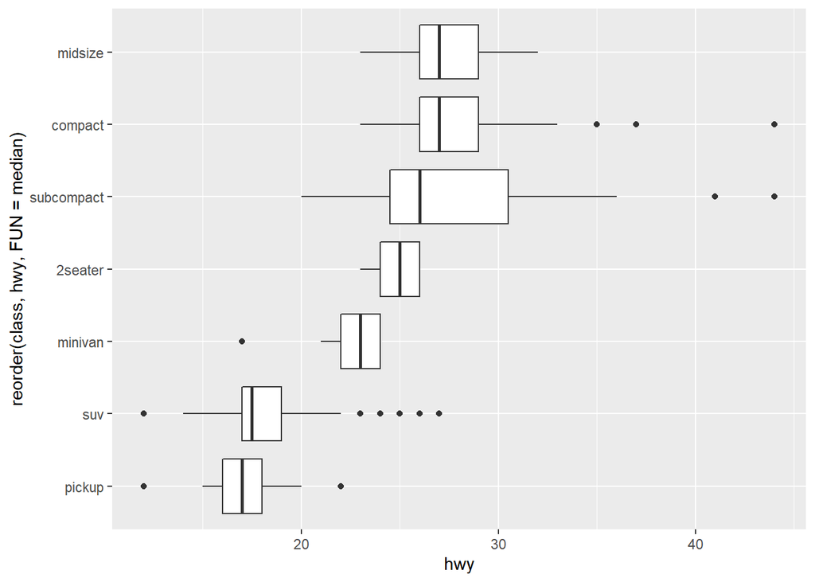

```r
ggplot(data = mpg) +
    geom_boxploth(mapping = aes(y = reorder(class, hwy, FUN = median), x = hwy))
```

### With large data, instead of boxploth (which displays “outlying values”) geom_lv drom the library (“lvplot”).

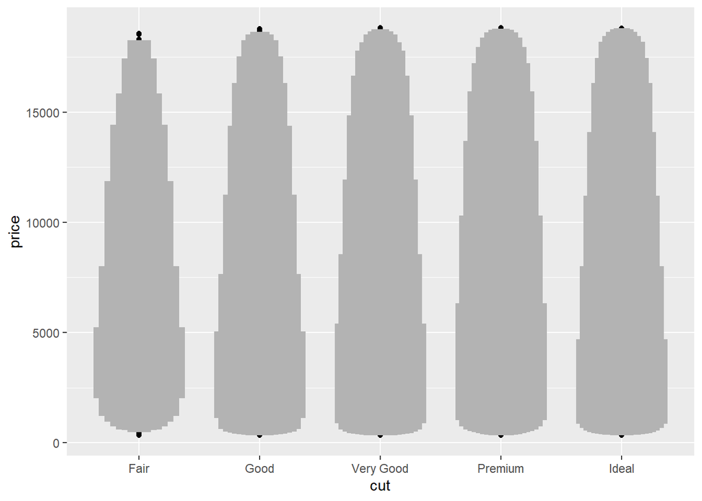

```r
ggplot(diamonds, aes(x = cut, y = price)) +
  geom_lv()
```

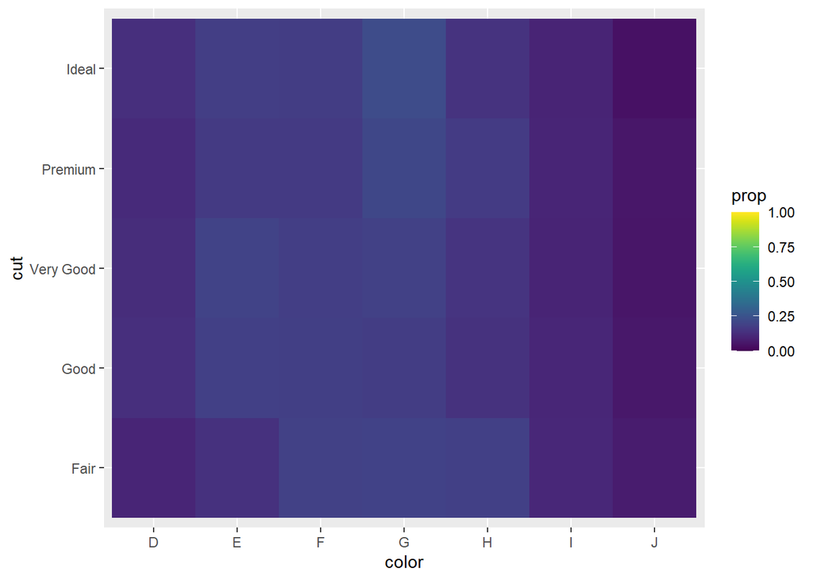

```r
diamonds %>%
    count(color, cut) %>%
    group_by(cut) %>%
    mutate(prop = n / sum(n)) %>%
    ggplot(mapping = aes(x = color, y = cut)) +
    geom_tile(mapping = aes(fill = prop)) +
    scale_fill_viridis(limits = c(0,1))
```

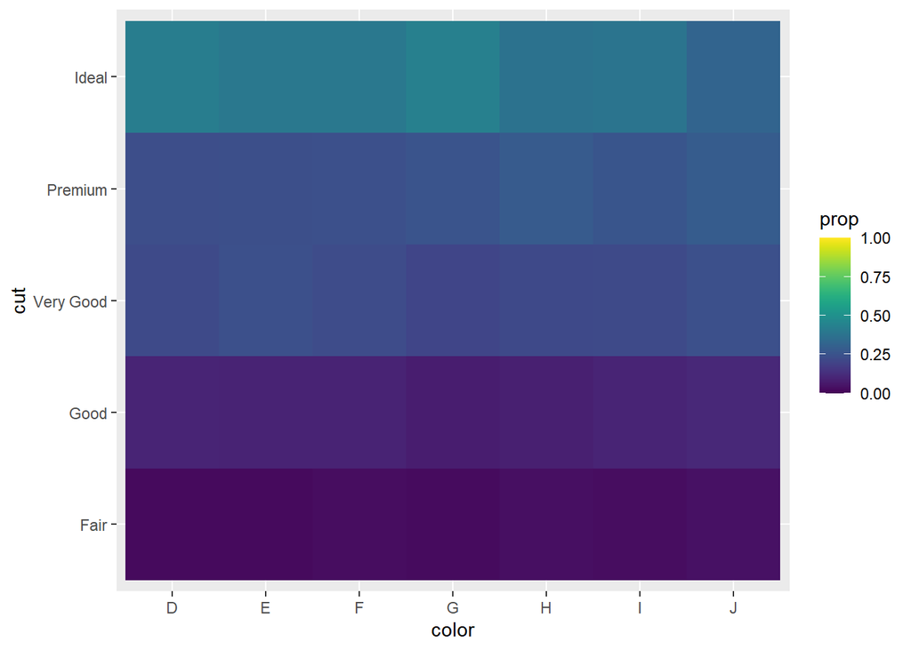

```r
diamonds %>%
  count(color, cut) %>%
  group_by(color) %>%
  mutate(prop = n / sum(n)) %>%
  ggplot(mapping = aes(x = color, y = cut)) +
  geom_tile(mapping = aes(fill = prop)) +
  scale_fill_viridis(limits = c(0, 1)) # from the viridis colour palette library
```

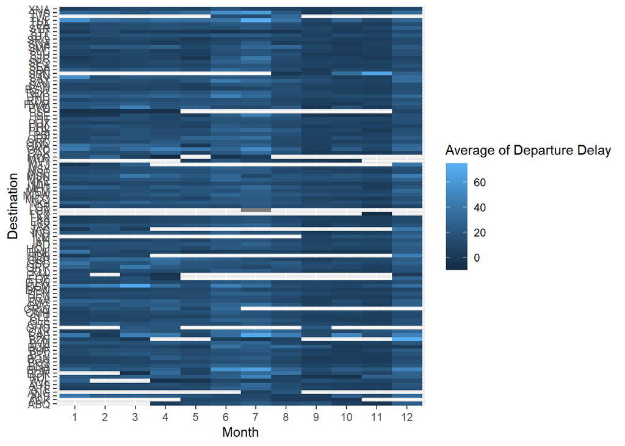

```r
flights %>%
    group_by(month, dest) %>%
    summarise(dep_delay = mean(dep_delay, na.rm = TRUE)) %>%
    ggplot(aes(x = factor(month), y = dest, fill = dep_delay)) +
    geom_tile() +
    labs(x = "Month", y = "Destination", fill = "Average of Departure Delay")
```